# 12.Example 1

Modified

Mo 2026-09-21 21:31

## Given:

A small surface of area $A_1=0.001\ \mathrm{m}^{2}$ is known to emit diffusely, and from measurements the total intensity associated with emission in the normal direction is $I_n=7000\ \frac{\mathrm{W}}{\left(\mathrm{m}^{2} \cdot \mathrm{sr}\right)}$. Radiation emitted from the surface is intercepted by three other surfaces of area $A_2=A_3=A_4=0.001\ \mathrm{m}^{2}$, which are $0.5\ \mathrm{m}$ from $A_1$ and are oriented as shown.

Figure 1: System Diagram

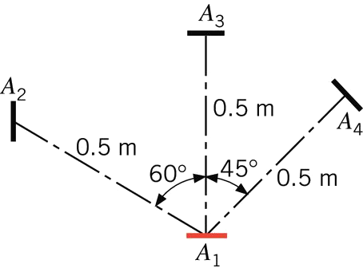

## Required:

What is the intensity associated with emission in each of the three directions? What are the solid angles subtended by the three surfaces when viewed from $A_1$? What is the rate at which radiation emitted by $A_1$ is intercepted by the three surfaces?

## Solution:

Start first by defining all of the given values.

$$A_1 = 0.001\ \mathrm{m}^{2}$$
$$I_n = 7000\ \frac{\mathrm{W}}{\left(\mathrm{m}^{2} \cdot \mathrm{sr}\right)}$$
$$A_2 = A_3 = A_4 = 0.001\ \mathrm{m}^{2}$$
$$r = 0.5\ \mathrm{m}$$

Since the emitter is described as being diffuse, there is no directional aspect to the intensity. Thus the normal intensity is equal to the intensities at all of the surfaces. That is

Answer, part 1: $I_2 = I_3 = I_4 = I_n = 7000\ \frac{\mathrm{W}}{\left(\mathrm{m}^{2} \cdot \mathrm{sr}\right)}$

To determine the solid angle of each of the surfaces, the definition of the solid angle may be used. This is shown below in the differential form.

$$d\omega = \frac{dA_n}{r^2}$$

This expressed in the non-differential form is

$$\omega = \frac{A_n}{r^2}$$

where $A_n$ is the normal area with respect to the line of path between the two surfaces. A sketch of the various surfaces and their normal areas are shown below.

Figure 2: System Sketch

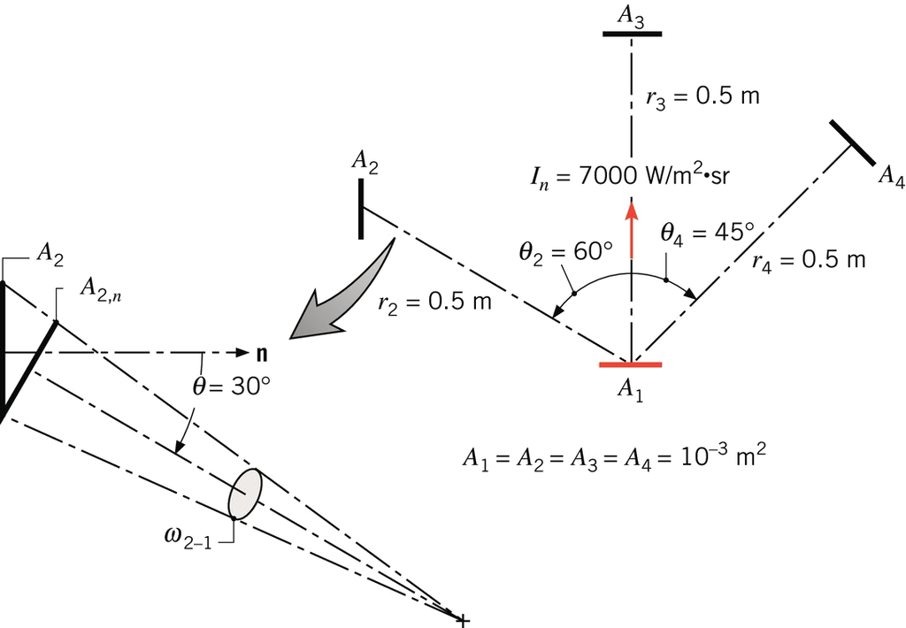

The various angles are defined below.

$$\theta_2 = 60 ^ \circ$$
$$\theta_3 = 0 ^ \circ$$
$$\theta_4 = 45 ^ \circ$$

The normal area of surface 2 is given by

$$A_{2,n} = A_2 sin ( \theta_2 ) = 0.000866\ \mathrm{m}^{2}$$

The solid angle that results between surface 1 and 2 is then given by

Answer, part 2.1: $\omega_{2-1} = \frac{A_{2n}}{r^2} = 0.003464\ \mathrm{sr}$

For surfaces 3 and 4, the surface area is already the normal surface area. Thus the solid angles are

Answer, part 2.2: $\omega_{3-1} = \frac{A_3}{r^2} = 0.004\ \mathrm{sr}$

Answer, part 2.3: $\omega_{4-1} = \frac{A_4}{r^2} = 0.004\ \mathrm{sr}$

To determine the rate of intercepted radiation, the definition of heat rate for radiation from an emitting body in the differential form may be used. This is shown below.

$$q_\lambda=I\left(\lambda, \theta, \phi\right)dA \cos\left(\theta\right)d\omega$$

This form may be simplified by first recognizing that the emitter is diffuse. That is

$$I=I_n\neq f\left(\lambda, \omega, \phi\right)$$

The second bit of information needed is to approximate the differential area $dA$ as the intercepting area. That is

$$dA \approx A$$

Since the areas are very small, this is not a bad approximation. Thus the heat rate expression becomes

$$q=IA\cos\theta \omega$$

The heat rate intercepted by the various surfaces are then

Answer, part 3.1: $q_{1-2} = I_n A_1 \cos(\theta_2) \omega_{2-1} = 12.12\ \mathrm{mW}$

Answer, part 3.2: $q_{1-3} = I_n A_1 \cos(\theta_3) \omega_{3-1} = 28.0\ \mathrm{mW}$

Answer, part 3.3: $q_{1-4} = I_n A_1 \cos(\theta_4) \omega_{4-1} = 19.8\ \mathrm{mW}$